# E-commerce Customer Purchase Intentions

Sümeyra Özuğur

170709046

## Required Libraries

```r
library(skimr)
library(RANN)
library(randomForest)
library(fastAdaboost)
library(gbm)
library(xgboost)
library(caretEnsemble)
library(C50)
library(earth)

library(mice)#kayıp gözlem
library(ggplot2)
library(lattice)
library(lava)
library(purrr)
library(caret)

library(naivebayes)
library(rlang)
library(e1071)
library(caTools)
```

### 1)Import “online_shoppers_intention.csv” dataset

First I should know my data. I checked Column names, row names. I checked what is in my data,

```r
#import data
mydata = read.csv("online_shoppers_intention.csv")
```

```r
str(mydata)
```

```
## 'data.frame':    12330 obs. of  18 variables:
##  $ Administrative         : int  0 0 0 0 0 0 0 1 0 0 ...
##  $ Administrative_Duration: num  0 0 0 0 0 0 0 0 0 0 ...
##  $ Informational          : int  0 0 0 0 0 0 0 0 0 0 ...
##  $ Informational_Duration : num  0 0 0 0 0 0 0 0 0 0 ...
##  $ ProductRelated         : int  1 2 1 2 10 19 1 0 2 3 ...
##  $ ProductRelated_Duration: num  0 64 0 2.67 627.5 ...
##  $ BounceRates            : num  0.2 0 0.2 0.05 0.02 ...
##  $ ExitRates              : num  0.2 0.1 0.2 0.14 0.05 ...
##  $ PageValues             : num  0 0 0 0 0 0 0 0 0 0 ...
##  $ SpecialDay             : num  0 0 0 0 0 0 0.4 0 0.8 0.4 ...
##  $ Month                  : chr  "Feb" "Feb" "Feb" "Feb" ...
##  $ OperatingSystems       : int  1 2 4 3 3 2 2 1 2 2 ...
##  $ Browser                : int  1 2 1 2 3 2 4 2 2 4 ...
##  $ Region                 : int  1 1 9 2 1 1 3 1 2 1 ...
##  $ TrafficType            : int  1 2 3 4 4 3 3 5 3 2 ...
##  $ VisitorType            : chr  "Returning_Visitor" "Returning_Visitor" "Returning_Visitor" "Returning_Visitor" ...
##  $ Weekend                : logi  FALSE FALSE FALSE FALSE TRUE FALSE ...
##  $ Revenue                : logi  FALSE FALSE FALSE FALSE FALSE FALSE ...
```

The data types in the dataset are numeric, character, int, logical.

```r
head(mydata)
```

```
##   Administrative Administrative_Duration Informational Informational_Duration
## 1              0                       0             0                      0
## 2              0                       0             0                      0
## 3              0                       0             0                      0
## 4              0                       0             0                      0
## 5              0                       0             0                      0
## 6              0                       0             0                      0
##   ProductRelated ProductRelated_Duration BounceRates ExitRates PageValues
## 1              1                0.000000  0.20000000 0.2000000          0
## 2              2               64.000000  0.00000000 0.1000000          0
## 3              1                0.000000  0.20000000 0.2000000          0
## 4              2                2.666667  0.05000000 0.1400000          0
## 5             10              627.500000  0.02000000 0.0500000          0
## 6             19              154.216667  0.01578947 0.0245614          0
##   SpecialDay Month OperatingSystems Browser Region TrafficType
## 1          0   Feb                1       1      1           1
## 2          0   Feb                2       2      1           2
## 3          0   Feb                4       1      9           3
## 4          0   Feb                3       2      2           4
## 5          0   Feb                3       3      1           4
## 6          0   Feb                2       2      1           3
##         VisitorType Weekend Revenue
## 1 Returning_Visitor   FALSE   FALSE
## 2 Returning_Visitor   FALSE   FALSE
## 3 Returning_Visitor   FALSE   FALSE
## 4 Returning_Visitor   FALSE   FALSE
## 5 Returning_Visitor    TRUE   FALSE
## 6 Returning_Visitor   FALSE   FALSE
```

You can also check na by using the mice package.

```r
sum(is.na(mydata))#0 is there na or not
```

```
## [1] 0
```

```r
#md.pattern(mydata)# is there na or not
colnames(mydata)
```

```
##  [1] "Administrative"          "Administrative_Duration"
##  [3] "Informational"           "Informational_Duration"
##  [5] "ProductRelated"          "ProductRelated_Duration"
##  [7] "BounceRates"             "ExitRates"
##  [9] "PageValues"              "SpecialDay"
## [11] "Month"                   "OperatingSystems"
## [13] "Browser"                 "Region"
## [15] "TrafficType"             "VisitorType"
## [17] "Weekend"                 "Revenue"
```

```r
#row.names(mydata)
```

# Data

Actually ,I know this dataset from midterm homework. To remember;

The dataset consists of users 12330 and there are 18 attributes in the dataset. There is no missing value in this dataset. 10 of them have Numerical features, rest of them have Categorical features, and **The goal of this dataset :** Trying to understand the intentions of online shoppers, Did she/he shop online or not. They also analyzed the shopping intent of different customers. Our response variable is the Revenue variable.

### Numerical features:

Administrative,Administrative duration, Informational, Informational duration, Product related, Bounce rate,Product related duration Exit rate,Page value, Special day

- **Administrative:** Number of pages visited by the visitor about account management
- **Administrative duration**: Total amount of time (in seconds) spent by the visitor on account management related pages
- **Informational:** Number of pages visited by the visitor about Web site, communication and address information of the shopping site
- **Informational duration:** Total amount of time (in seconds) spent by the visitor on informational pages.
- **Product related:** Number of pages visited by visitor about product related pages
- **Product related duration:** Total amount of time (in seconds) spent by the visitor on product related pages
- **Bounce rate:** Average bounce rate value of the pages visited by the visitor
- **Exit rate:** Average exit rate value of the pages visited by the visitor
- **Page value:** Average page value of the pages visited by the visitor
- **Special day:** Closeness of the site visiting time to a special day

### Categorical features:

VisitorType,Region, Browser, Operating Systems, TrafficType, Weekend, Month, Revenue

- **OperatingSystems:** Operating system of the visitor
- **Browser:** Browser of the visitor
- **Region:** Geographic region from which the session has been started by the visitor.
- **TrafficType:** Traffic source by which the visitor has arrived at the Web site (e.g., banner, SMS, direct)
- **VisitorType:** Visitor type as ‘‘New Visitor,’’ ‘‘Returning Visitor,’’ and ‘‘Other’’
- **Weekend:** Boolean value indicating whether the date of the visit is weekend
- **Month:** Month value of the visit date
- **Revenue:** Class label indicating whether the visit has been finalized with a transaction

Firstly; I split it into training(80%) and test(20%) By the way, I set list=F, to prevent returning the result as a list.

```r
set.seed(100)

trainRowNumbers <- createDataPartition(mydata$Revenue, p=0.8, list=FALSE)

trainData <- mydata[trainRowNumbers,]

testData <- mydata[-trainRowNumbers,]

x = trainData[, 1:17] #Revenue çıkarıldı
y= trainData$Revenue #Revenue tutuluyor
```

```r
skimmed <- skimr::skim(trainData)
skimmed[, ]
```

Data summary

| Name | trainData |
| --- | --- |
| Number of rows | 9865 |
| Number of columns | 18 |
| _______________________ |  |
| Column type frequency: |  |
| character | 2 |
| logical | 2 |
| numeric | 14 |
| ________________________ |  |
| Group variables | None |

**Variable type: character**

| skim_variable | n_missing | complete_rate | min | max | empty | n_unique | whitespace |
| --- | --- | --- | --- | --- | --- | --- | --- |
| Month | 0 | 1 | 3 | 4 | 0 | 10 | 0 |
| VisitorType | 0 | 1 | 5 | 17 | 0 | 3 | 0 |

**Variable type: logical**

| skim_variable | n_missing | complete_rate | mean | count |
| --- | --- | --- | --- | --- |
| Weekend | 0 | 1 | 0.24 | FAL: 7532, TRU: 2333 |
| Revenue | 0 | 1 | 0.15 | FAL: 8338, TRU: 1527 |

**Variable type: numeric**

| skim_variable | n_missing | complete_rate | mean | sd | p0 | p25 | p50 | p75 | p100 | hist |
| --- | --- | --- | --- | --- | --- | --- | --- | --- | --- | --- |
| Administrative | 0 | 1 | 2.31 | 3.32 | 0 | 0.00 | 1.00 | 4.00 | 27.00 | ▇▁▁▁▁ |
| Administrative_Duration | 0 | 1 | 81.23 | 177.80 | 0 | 0.00 | 7.00 | 94.00 | 3398.75 | ▇▁▁▁▁ |
| Informational | 0 | 1 | 0.50 | 1.26 | 0 | 0.00 | 0.00 | 0.00 | 24.00 | ▇▁▁▁▁ |
| Informational_Duration | 0 | 1 | 34.55 | 142.33 | 0 | 0.00 | 0.00 | 0.00 | 2549.38 | ▇▁▁▁▁ |
| ProductRelated | 0 | 1 | 31.52 | 44.18 | 0 | 7.00 | 18.00 | 38.00 | 705.00 | ▇▁▁▁▁ |
| ProductRelated_Duration | 0 | 1 | 1187.54 | 1932.14 | 0 | 186.93 | 606.50 | 1461.42 | 63973.52 | ▇▁▁▁▁ |
| BounceRates | 0 | 1 | 0.02 | 0.05 | 0 | 0.00 | 0.00 | 0.02 | 0.20 | ▇▁▁▁▁ |
| ExitRates | 0 | 1 | 0.04 | 0.05 | 0 | 0.01 | 0.03 | 0.05 | 0.20 | ▇▂▁▁▁ |
| PageValues | 0 | 1 | 5.78 | 17.89 | 0 | 0.00 | 0.00 | 0.00 | 360.95 | ▇▁▁▁▁ |
| SpecialDay | 0 | 1 | 0.06 | 0.20 | 0 | 0.00 | 0.00 | 0.00 | 1.00 | ▇▁▁▁▁ |
| OperatingSystems | 0 | 1 | 2.12 | 0.90 | 1 | 2.00 | 2.00 | 3.00 | 8.00 | ▇▂▁▁▁ |
| Browser | 0 | 1 | 2.35 | 1.71 | 1 | 2.00 | 2.00 | 2.00 | 13.00 | ▇▁▁▁▁ |
| Region | 0 | 1 | 3.14 | 2.40 | 1 | 1.00 | 3.00 | 4.00 | 9.00 | ▇▅▁▂▁ |
| TrafficType | 0 | 1 | 4.10 | 4.03 | 1 | 2.00 | 2.00 | 4.00 | 20.00 | ▇▁▁▁▁ |

```r
anyNA(trainData)
```

```
## [1] FALSE
```

We can see the column features in more detail. As you see Training data has 9865 rows, and 18 colomns, There is no missing value in the dataset, so there is no missing value in training set.

```r
# One-Hot Encoding

dummies_model <- dummyVars(Revenue ~ ., data=trainData)

trainData_mat <- predict(dummies_model, newdata = trainData)

# # Convert to dataframe
trainData <- data.frame(trainData_mat)

# # See the structure of the new dataset
str(trainData)
```

```
## 'data.frame':    9865 obs. of  29 variables:
##  $ Administrative              : num  0 0 0 0 0 0 1 0 0 0 ...
##  $ Administrative_Duration     : num  0 0 0 0 0 0 0 0 0 0 ...
##  $ Informational               : num  0 0 0 0 0 0 0 0 0 0 ...
##  $ Informational_Duration      : num  0 0 0 0 0 0 0 0 0 0 ...
##  $ ProductRelated              : num  1 2 2 10 19 1 0 2 3 16 ...
##  $ ProductRelated_Duration     : num  0 64 2.67 627.5 154.22 ...
##  $ BounceRates                 : num  0.2 0 0.05 0.02 0.0158 ...
##  $ ExitRates                   : num  0.2 0.1 0.14 0.05 0.0246 ...
##  $ PageValues                  : num  0 0 0 0 0 0 0 0 0 0 ...
##  $ SpecialDay                  : num  0 0 0 0 0 0.4 0 0.8 0.4 0.4 ...
##  $ MonthAug                    : num  0 0 0 0 0 0 0 0 0 0 ...
##  $ MonthDec                    : num  0 0 0 0 0 0 0 0 0 0 ...
##  $ MonthFeb                    : num  1 1 1 1 1 1 1 1 1 1 ...
##  $ MonthJul                    : num  0 0 0 0 0 0 0 0 0 0 ...
##  $ MonthJune                   : num  0 0 0 0 0 0 0 0 0 0 ...
##  $ MonthMar                    : num  0 0 0 0 0 0 0 0 0 0 ...
##  $ MonthMay                    : num  0 0 0 0 0 0 0 0 0 0 ...
##  $ MonthNov                    : num  0 0 0 0 0 0 0 0 0 0 ...
##  $ MonthOct                    : num  0 0 0 0 0 0 0 0 0 0 ...
##  $ MonthSep                    : num  0 0 0 0 0 0 0 0 0 0 ...
##  $ OperatingSystems            : num  1 2 3 3 2 2 1 2 2 1 ...
##  $ Browser                     : num  1 2 2 3 2 4 2 2 4 1 ...
##  $ Region                      : num  1 1 2 1 1 3 1 2 1 4 ...
##  $ TrafficType                 : num  1 2 4 4 3 3 5 3 2 3 ...
##  $ VisitorTypeNew_Visitor      : num  0 0 0 0 0 0 0 0 0 0 ...
##  $ VisitorTypeOther            : num  0 0 0 0 0 0 0 0 0 0 ...
##  $ VisitorTypeReturning_Visitor: num  1 1 1 1 1 1 1 1 1 1 ...
##  $ WeekendFALSE                : num  1 1 1 0 1 1 0 1 1 1 ...
##  $ WeekendTRUE                 : num  0 0 0 1 0 0 1 0 0 0 ...
```

It was one-hot-encoded to produce new columns for VisitorType, Weekend, and Months. As you see we have 29 columns now.

```r
preProcess_range_model <- preProcess(trainData, method='range')
trainData <- predict(preProcess_range_model, newdata = trainData)

apply(trainData[, 1:29],2, FUN=function(x){c('min'=min(x), 'max'=max(x))})
```

```
##     Administrative Administrative_Duration Informational Informational_Duration
## min              0                       0             0                      0
## max              1                       1             1                      1
##     ProductRelated ProductRelated_Duration BounceRates ExitRates PageValues
## min              0                       0           0         0          0
## max              1                       1           1         1          1
##     SpecialDay MonthAug MonthDec MonthFeb MonthJul MonthJune MonthMar MonthMay
## min          0        0        0        0        0         0        0        0
## max          1        1        1        1        1         1        1        1
##     MonthNov MonthOct MonthSep OperatingSystems Browser Region TrafficType
## min        0        0        0                0       0      0           0
## max        1        1        1                1       1      1           1
##     VisitorTypeNew_Visitor VisitorTypeOther VisitorTypeReturning_Visitor
## min                      0                0                            0
## max                      1                1                            1
##     WeekendFALSE WeekendTRUE
## min            0           0
## max            1           1
```

```r
trainData$Revenue <- y

trainData$Revenue <- as.factor(trainData$Revenue)
class(trainData$Revenue)
```

```
## [1] "factor"
```

# Visualize Your Variables

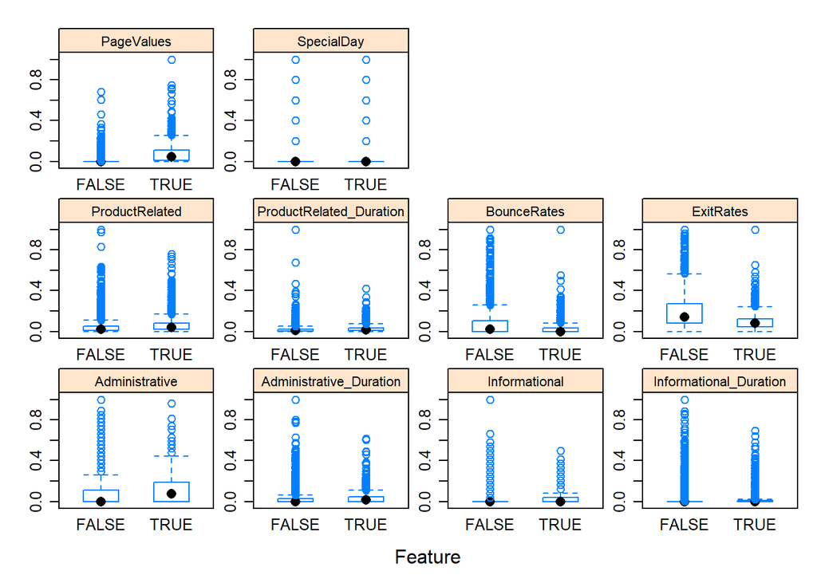

```r
featurePlot(x = trainData[, 1:10], #1:10
            y = trainData$Revenue,
            plot = "box",
            strip=strip.custom(par.strip.text=list(cex=.7)),
            scales = list(y = list(relation="free"),
                          x = list(relation="free")))
```

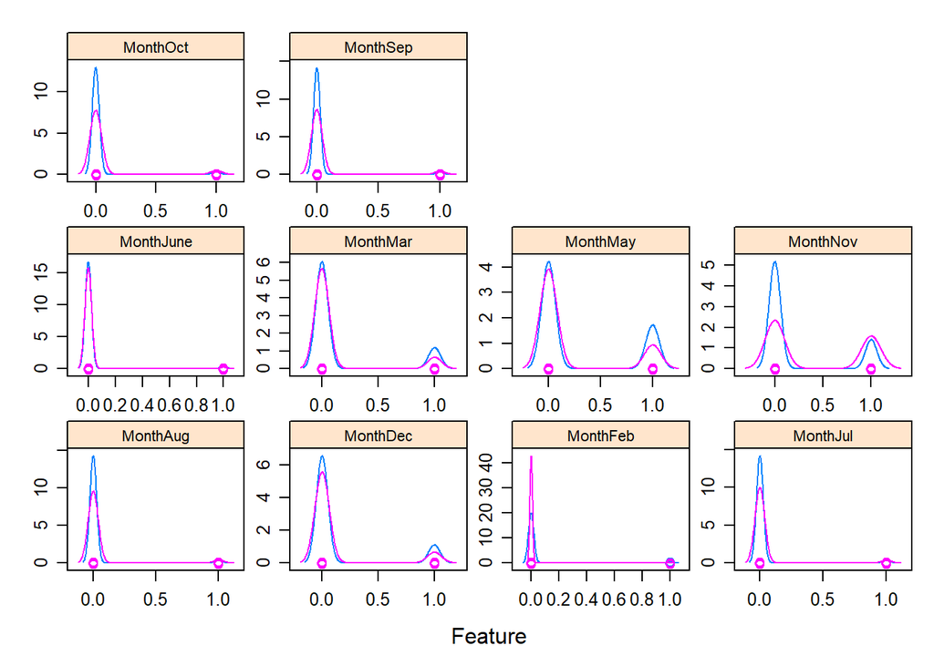

```r
featurePlot(x = trainData[, 11:20],
           y = trainData$Revenue,
           plot = "density",
           strip=strip.custom(par.strip.text=list(cex=.7)),
           scales = list(x = list(relation="free"),
                         y = list(relation="free")))
```

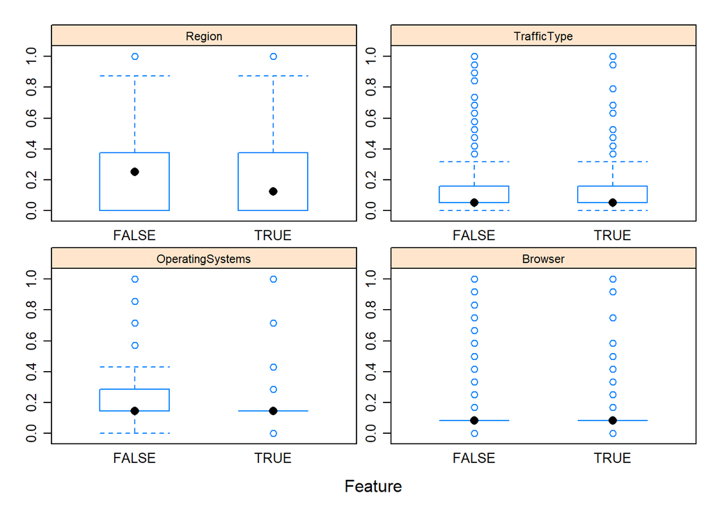

```r
featurePlot(x = trainData[, 21:24,28:29],
           y = trainData$Revenue,
           plot = "box",
           strip=strip.custom(par.strip.text=list(cex=.7)),
           scales = list(x = list(relation="free"),
                         y = list(relation="free")))
```

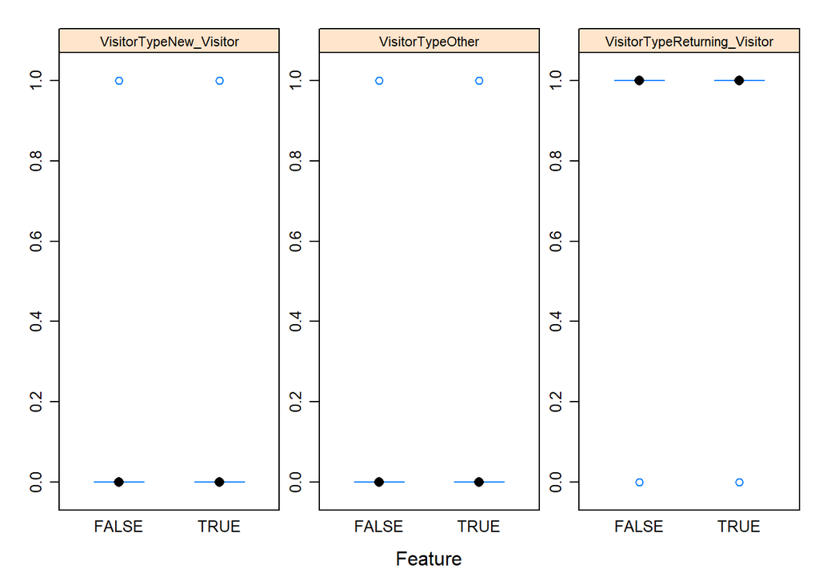

```r
featurePlot(x = trainData[, 25:27],
           y = trainData$Revenue,
           plot = "box",
           strip=strip.custom(par.strip.text=list(cex=.7)),
           scales = list(x = list(relation="free"),
                         y = list(relation="free")))
```

I use box plots and density plots. You can use other plots if you want. Boxplot is easier for me

# Training

```r
set.seed(100)

model_knn = train(Revenue ~ ., data=trainData, method='knn')
```

```r
model_knn
```

```
## k-Nearest Neighbors
##
## 9865 samples
##   29 predictor
##    2 classes: 'FALSE', 'TRUE'
##
## No pre-processing
## Resampling: Bootstrapped (25 reps)
## Summary of sample sizes: 9865, 9865, 9865, 9865, 9865, 9865, ...
## Resampling results across tuning parameters:
##
##   k  Accuracy   Kappa
##   5  0.8259528  0.2092942
##   7  0.8328089  0.1944687
##   9  0.8395105  0.1889336
##
## Accuracy was used to select the optimal model using the largest value.
## The final value used for the model was k = 9.
```

Our accuracy value is the highest for K = 9, Kappa has the highest value for k = 5.

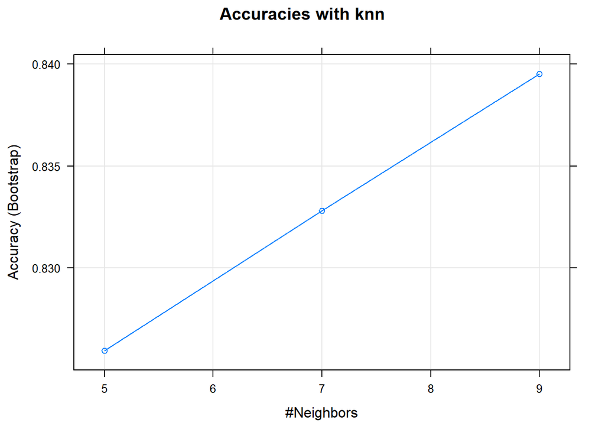

```r
plot(model_knn, main="Accuracies with knn")
```

this chart show accuracy based on k values

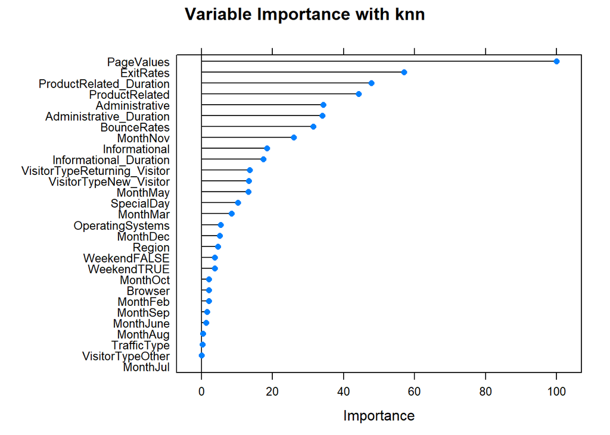

```r
varimp_knn <- varImp(model_knn)
plot(varimp_knn, main = "Variable Importance with knn",
                 check_overlap = TRUE)
```

In this chart you will see the order of importance of the columns. As you see PageValues is most important , ExitRates is second important.

# Prediction

```r
testData$Revenue <- as.factor(testData$Revenue)
```

```r
testData3 <- predict(dummies_model, testData)

testData4 <- predict(preProcess_range_model, testData3)
```

```r
fitted <- predict(model_knn, testData4)


confusionMatrix(reference = testData$Revenue, data = fitted, mode='everything', positive='TRUE')
```

```
## Confusion Matrix and Statistics
##
##           Reference
## Prediction FALSE TRUE
##      FALSE  2042  329
##      TRUE     42   52
##
##                Accuracy : 0.8495
##                  95% CI : (0.8348, 0.8634)
##     No Information Rate : 0.8454
##     P-Value [Acc > NIR] : 0.2999
##
##                   Kappa : 0.1681
##
##  Mcnemar's Test P-Value : <2e-16
##
##             Sensitivity : 0.13648
##             Specificity : 0.97985
##          Pos Pred Value : 0.55319
##          Neg Pred Value : 0.86124
##               Precision : 0.55319
##                  Recall : 0.13648
##                      F1 : 0.21895
##              Prevalence : 0.15456
##          Detection Rate : 0.02110
##    Detection Prevalence : 0.03813
##       Balanced Accuracy : 0.55816
##
##        'Positive' Class : TRUE
##
```

2094 of our data in TestData4(2.465) were correctly estimated. Accuracy is 0.85, Sensitivity is low(%14).

# Training other models

```r
set.seed(100)
model_nb = train(Revenue ~ ., data=trainData, method='naive_bayes')
model_nb
```

```
## Naive Bayes
##
## 9865 samples
##   29 predictor
##    2 classes: 'FALSE', 'TRUE'
##
## No pre-processing
## Resampling: Bootstrapped (25 reps)
## Summary of sample sizes: 9865, 9865, 9865, 9865, 9865, 9865, ...
## Resampling results across tuning parameters:
##
##   usekernel  Accuracy   Kappa
##   FALSE      0.6843067  0.2800215
##    TRUE      0.8604620  0.1944250
##
## Tuning parameter 'laplace' was held constant at a value of 0
## Tuning
##  parameter 'adjust' was held constant at a value of 1
## Accuracy was used to select the optimal model using the largest value.
## The final values used for the model were laplace = 0, usekernel = TRUE
##  and adjust = 1.
```

As you see , trainData has 9865 samples, 29 predictor, 2 classes(FALSE and TRUE) and according to Naive Bayes accuracy is higher for usekernel True value. Kappa is higher for usekernel False value.

```r
set.seed(100)
model_lda = train(Revenue ~ ., data=trainData, method='lda')
model_lda
```

```
## Linear Discriminant Analysis
##
## 9865 samples
##   29 predictor
##    2 classes: 'FALSE', 'TRUE'
##
## No pre-processing
## Resampling: Bootstrapped (25 reps)
## Summary of sample sizes: 9865, 9865, 9865, 9865, 9865, 9865, ...
## Resampling results:
##
##   Accuracy   Kappa
##   0.8830559  0.4220005
```

According to Linear Discriminant Analysis, accuracy is 88% and Kappa is 42%.

```r
set.seed(100)

model_tree = train(Revenue ~ ., data=trainData, method='rpart')
model_tree
```

```
## CART
##
## 9865 samples
##   29 predictor
##    2 classes: 'FALSE', 'TRUE'
##
## No pre-processing
## Resampling: Bootstrapped (25 reps)
## Summary of sample sizes: 9865, 9865, 9865, 9865, 9865, 9865, ...
## Resampling results across tuning parameters:
##
##   cp          Accuracy   Kappa
##   0.04518664  0.8927833  0.5440815
##   0.06876228  0.8890409  0.5225213
##   0.23903078  0.8601594  0.2354588
##
## Accuracy was used to select the optimal model using the largest value.
## The final value used for the model was cp = 0.04518664.
```

According to Cart, highest accuracy is 89% and highest kappa is 54%.

```r
models_compare <- resamples(list(KNN=model_knn, LDA=model_lda, DECISIONTREE=model_tree, NAIVEBAYES=model_nb))

summary(models_compare)
```

```
##
## Call:
## summary.resamples(object = models_compare)
##
## Models: KNN, LDA, DECISIONTREE, NAIVEBAYES
## Number of resamples: 25
##
## Accuracy
##                   Min.   1st Qu.    Median      Mean   3rd Qu.      Max. NA's
## KNN          0.8300191 0.8365411 0.8389482 0.8395105 0.8419346 0.8538124    0
## LDA          0.8758678 0.8803630 0.8827586 0.8830559 0.8861346 0.8894893    0
## DECISIONTREE 0.8812208 0.8891951 0.8932569 0.8927833 0.8961749 0.9062416    0
## NAIVEBAYES   0.8496513 0.8571822 0.8606557 0.8604620 0.8645517 0.8666293    0
##
## Kappa
##                    Min.   1st Qu.    Median      Mean   3rd Qu.      Max. NA's
## KNN          0.15125484 0.1731608 0.1944564 0.1889336 0.2013940 0.2289091    0
## LDA          0.39327116 0.4081142 0.4215090 0.4220005 0.4363977 0.4522794    0
## DECISIONTREE 0.46052722 0.5038835 0.5583037 0.5440815 0.5841721 0.6082024    0
## NAIVEBAYES   0.03614467 0.1752933 0.1957660 0.1944250 0.2170204 0.2776185    0
```

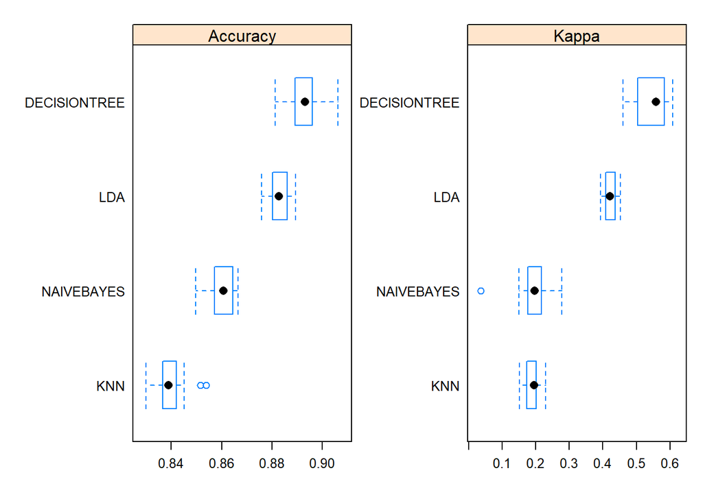

```r
# Draw box plots to compare models
scales <- list(x=list(relation="free"), y=list(relation="free"))
bwplot(models_compare, scales=scales)
```

**The model with the highest accuracy value** is DecisionTree and The model with the lowest accuracy value is knn. By the way The model with the highest kappa value is DecisionTree. `

```r
fitted <- predict(model_nb, testData4)
fitted <- predict(model_lda, testData4)
fitted <- predict(model_tree, testData4)
```

```r
# Define the training control
fitControl <- trainControl(
    method = 'cv',                   # k-fold cross validation
    number = 10                      # number of folds
)
```

```r
set.seed(100)
# Train the model using naive bayes
model_knn = train(Revenue ~ ., data=trainData, method='knn',
                  trControl=fitControl)
model_knn
```

```
## k-Nearest Neighbors
##
## 9865 samples
##   29 predictor
##    2 classes: 'FALSE', 'TRUE'
##
## No pre-processing
## Resampling: Cross-Validated (10 fold)
## Summary of sample sizes: 8879, 8878, 8878, 8878, 8879, 8879, ...
## Resampling results across tuning parameters:
##
##   k  Accuracy   Kappa
##   5  0.8493673  0.2328713
##   7  0.8516978  0.1970911
##   9  0.8545366  0.1940018
##
## Accuracy was used to select the optimal model using the largest value.
## The final value used for the model was k = 9.
```

According to k-Nearest Neighbors highest accuracy is k=9 for Cross-Valid(10) in TrainData, highest Kappa is k=5 .

```r
set.seed(100)
# Train the model using naive bayes
model_nb = train(Revenue ~ ., data=trainData, method='naive_bayes',
                 trControl=fitControl)
model_nb
```

```
## Naive Bayes
##
## 9865 samples
##   29 predictor
##    2 classes: 'FALSE', 'TRUE'
##
## No pre-processing
## Resampling: Cross-Validated (10 fold)
## Summary of sample sizes: 8879, 8878, 8878, 8878, 8879, 8879, ...
## Resampling results across tuning parameters:
##
##   usekernel  Accuracy   Kappa
##   FALSE      0.6900177  0.2852267
##    TRUE      0.8605162  0.2068261
##
## Tuning parameter 'laplace' was held constant at a value of 0
## Tuning
##  parameter 'adjust' was held constant at a value of 1
## Accuracy was used to select the optimal model using the largest value.
## The final values used for the model were laplace = 0, usekernel = TRUE
##  and adjust = 1.
```

According to Naive Bayes highest accuracy is 86% for TRUE value of usekernel in TrainData, highest Kappa is 28% for FALSE value of usekernel.

```r
set.seed(100)
# Train the model using lda
model_lda = train(Revenue ~ ., data=trainData, method='lda',
                   trControl=fitControl)
model_lda
```

```
## Linear Discriminant Analysis
##
## 9865 samples
##   29 predictor
##    2 classes: 'FALSE', 'TRUE'
##
## No pre-processing
## Resampling: Cross-Validated (10 fold)
## Summary of sample sizes: 8879, 8878, 8878, 8878, 8879, 8879, ...
## Resampling results:
##
##   Accuracy   Kappa
##   0.8811966  0.4171765
```

Acording to Linear Discriminant Analysis accuracy is 88% and kappa is 41% for cross validated(10).

```r
set.seed(100)
# Train the model using lda
model_tree = train(Revenue ~ ., data=trainData, method='rpart',
                    trControl=fitControl)
model_tree
```

```
## CART
##
## 9865 samples
##   29 predictor
##    2 classes: 'FALSE', 'TRUE'
##
## No pre-processing
## Resampling: Cross-Validated (10 fold)
## Summary of sample sizes: 8879, 8878, 8878, 8878, 8879, 8879, ...
## Resampling results across tuning parameters:
##
##   cp          Accuracy   Kappa
##   0.04518664  0.8931562  0.5491614
##   0.06876228  0.8823122  0.5252732
##   0.23903078  0.8605159  0.2858883
##
## Accuracy was used to select the optimal model using the largest value.
## The final value used for the model was cp = 0.04518664.
```

Acording to Cart highest accuracy is 89% and kappa is 54% for cross validated .

```r
# Compare model performances using resample()
models_compare <- resamples(list(KNN=model_knn, LDA=model_lda, DECISIONTREE=model_tree, NAIVEBAYES=model_nb))

# Summary of the models performances
summary(models_compare)
```

```
##
## Call:
## summary.resamples(object = models_compare)
##
## Models: KNN, LDA, DECISIONTREE, NAIVEBAYES
## Number of resamples: 10
##
## Accuracy
##                   Min.   1st Qu.    Median      Mean   3rd Qu.      Max. NA's
## KNN          0.8480243 0.8521805 0.8555496 0.8545366 0.8578665 0.8590264    0
## LDA          0.8703141 0.8778823 0.8808316 0.8811966 0.8839919 0.8924949    0
## DECISIONTREE 0.8824721 0.8877630 0.8914807 0.8931562 0.8978958 0.9098278    0
## NAIVEBAYES   0.8519270 0.8590264 0.8596049 0.8605162 0.8639818 0.8652482    0
##
## Kappa
##                   Min.   1st Qu.    Median      Mean   3rd Qu.      Max. NA's
## KNN          0.1556111 0.1730796 0.1932042 0.1940018 0.2123698 0.2409588    0
## LDA          0.3530388 0.3920810 0.4172222 0.4171765 0.4443564 0.4822301    0
## DECISIONTREE 0.5007457 0.5221478 0.5500345 0.5491614 0.5589845 0.6353595    0
## NAIVEBAYES   0.1492867 0.1834997 0.2104042 0.2068261 0.2266250 0.2692377    0
```

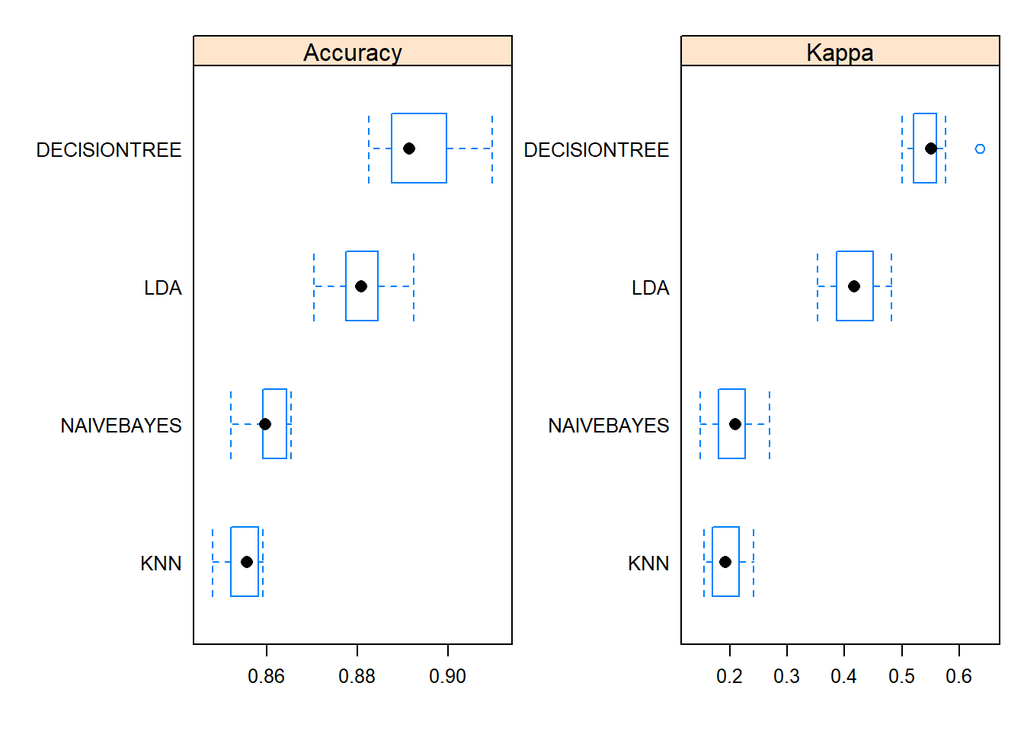

```r
# Draw box plots to compare models
scales <- list(x=list(relation="free"), y=list(relation="free"))
bwplot(models_compare, scales=scales)
```

**After with cross validation,** our data starts with an accuracy of 0.86, and starts with a kappa of 0.2

```r
set.seed(100)

subsets <- c(1,2, 5:8, 18)
```

we ordered of importance of the columns with knn before. I analyzed them and thought these columns were more important.

```r
ctrl <- rfeControl(functions = rfFuncs,
                   method = "repeatedcv",
                   repeats = 1,verbose = FALSE)
```

# Conclusion:

I could not run some of the last chunks due to the large data and my internet being slow. I tried by removing some columns but nothing changed. I added it again to avoid data loss. my chunk has been running for about 4 hours, but it doesn’t give any results. I would also send my so .rmd file, please check .rmd file out for the last chunks.

I have some guesses about these codes. The highest accuracy is decision tree, lowest accuracy is knn.